# Volcano Eruptions(2020_20) - TidyTuesday

[Allie Burns](https://allie-burns.github.io/)

2020-05-16

## Loading and exploring the data

```r
## Load in the libraries
library(ggplot2)
library(sf)
library(rnaturalearth)
library(rnaturalearthdata)
library(ggpomological)
library(dplyr)

## Install tidy data
devtools::install_github("thebioengineer/tidytuesdayR")
tuesdata <- tidytuesdayR::tt_load(2020, week = 20)

## Seperate files
volcano <- tuesdata$volcano
eruptions <- tuesdata$eruptions
events <- tuesdata$events
tree_rings <- tuesdata$tree_rings

volcano
```

```
## # A tibble: 958 x 26
##    volcano_number volcano_name primary_volcano… last_eruption_y… country region
##             <dbl> <chr>        <chr>            <chr>            <chr>   <chr>
##  1         283001 Abu          Shield(s)        -6850            Japan   Japan…
##  2         355096 Acamarachi   Stratovolcano    Unknown          Chile   South…
##  3         342080 Acatenango   Stratovolcano(e… 1972             Guatem… Méxic…
##  4         213004 Acigol-Nevs… Caldera          -2080            Turkey  Medit…
##  5         321040 Adams        Stratovolcano    950              United… Canad…
##  6         283170 Adatarayama  Stratovolcano(e… 1996             Japan   Japan…
##  7         221170 Adwa         Stratovolcano    Unknown          Ethiop… Afric…
##  8         221110 Afdera       Stratovolcano    Unknown          Ethiop… Afric…
##  9         284160 Agrigan      Stratovolcano    1917             United… Japan…
## 10         342100 Agua         Stratovolcano    Unknown          Guatem… Méxic…
## # … with 948 more rows, and 20 more variables: subregion <chr>, latitude <dbl>,
## #   longitude <dbl>, elevation <dbl>, tectonic_settings <chr>,
## #   evidence_category <chr>, major_rock_1 <chr>, major_rock_2 <chr>,
## #   major_rock_3 <chr>, major_rock_4 <chr>, major_rock_5 <chr>,
## #   minor_rock_1 <chr>, minor_rock_2 <chr>, minor_rock_3 <chr>,
## #   minor_rock_4 <chr>, minor_rock_5 <chr>, population_within_5_km <dbl>,
## #   population_within_10_km <dbl>, population_within_30_km <dbl>,
## #   population_within_100_km <dbl>
```

```r
world <- ne_countries(scale = "medium", returnclass = "sf")
```

## Visualizing the data

The data this week comes from The Smithsonian Institution.

Axios put together a lovely plot of volcano eruptions since Krakatoa (after 1883) by elevation and type.

First, I want to see where volcanos are located world-wide.

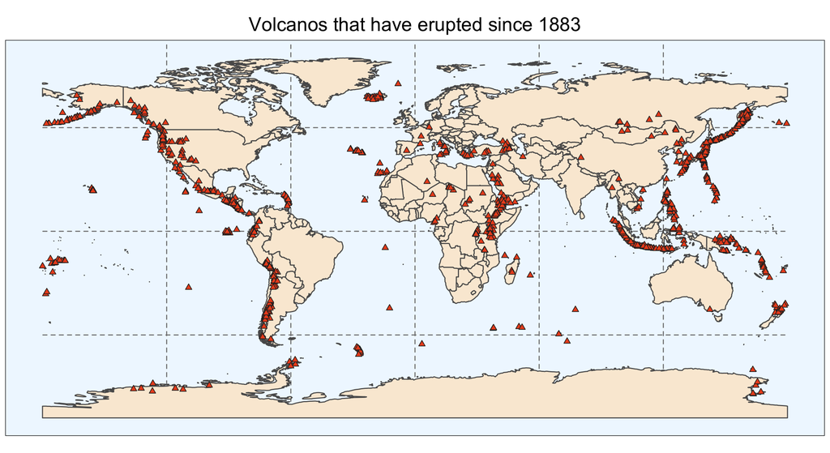

```r
world_volcanos <- ggplot(data = world) +
    geom_sf(fill= "antiquewhite") +
    geom_point(data = volcano, aes(x = longitude, y = latitude),
               color = "#292929", fill = "#EB5121",
               size = 2, shape = 24) +
    ggtitle("Volcanos that have erupted since 1883") +
    theme_classic() +
    theme(plot.title = element_text(hjust = 0.5, size=20),
          panel.grid.major = element_line(color = gray(.5),linetype = "dashed",size = 0.5),
          panel.background = element_rect(fill = "aliceblue",color="black"),
          axis.title.x=element_blank(),
          axis.title.y=element_blank())

world_volcanos
```

I’ve always known that volcanos were primarily found along fault lines but I really enjoy seeing how linear many of these volcanos really are. I was expecting to see more volcanos in oceans but it’s possible that a lot of the volcanos under water are not recorded in this dataset.

I also want to see which volcanos are located in regions where there are a lot of people. To get an idea of how the data looks. I’m mapping all of the volcanos from the previous plot.

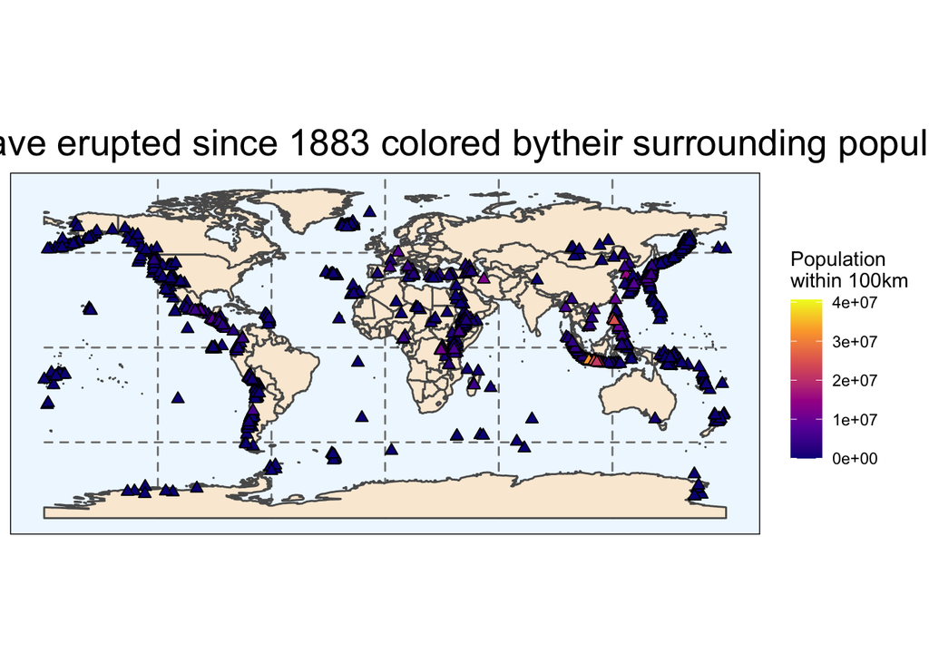

```r
all_population <- ggplot(data = world) +
    geom_sf(fill= "antiquewhite") +
    geom_point(data = volcano,
               aes(x = longitude, y = latitude, fill = population_within_100_km),
               size = 2, shape = 24) +
    scale_fill_viridis_c(option = "plasma") +
    ggtitle("Volcanos that have erupted since 1883 colored bytheir surrounding populations ") +
    labs(fill = "Population\nwithin 100km") +
    theme_classic() +
    theme(plot.title = element_text(hjust = 0.5, size=20),
          panel.grid.major = element_line(color = gray(.5),linetype = "dashed",size = 0.5),
          panel.background = element_rect(fill = "aliceblue",color="black"),
          axis.title.x=element_blank(),
          axis.title.y=element_blank())

all_population
```

It’s a bit busy so I’ll filter out volcanos that have less than the average number of people within a 100km radius.. Then I’ll map their populations within the blast zone (which in reality is usually less than 1km so this 5km likely represents people who would not immediately affected by the blast but by secondary effects).

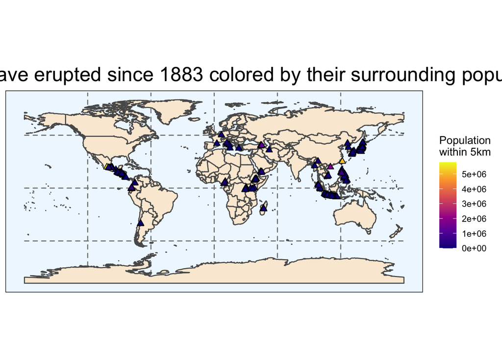

```r
## Filter any volcanos that don't have any people within 100 km
volFilt <- volcano %>%
    filter(population_within_100_km > mean(population_within_100_km,na.rm=TRUE))

highest_population <- ggplot(data = world) +
    geom_sf(fill= "antiquewhite") +
    geom_point(data = volFilt,
               aes(x = longitude, y = latitude, fill = population_within_5_km),
               size = 2, shape = 24) +
    scale_fill_viridis_c(option = "plasma") +
    ggtitle("Volcanos that have erupted since 1883 colored by their surrounding populations ") +
    labs(fill = "Population\nwithin 5km") +
    theme_classic() +
    theme(plot.title = element_text(hjust = 0.5, size=20),
          panel.grid.major = element_line(color = gray(.5),linetype = "dashed",size = 0.5),
          panel.background = element_rect(fill = "aliceblue",color="black"),
          axis.title.x=element_blank(),
          axis.title.y=element_blank())

highest_population
```

## Some notes about working in R markdown

In order to knit from the command line : `R -e "rmarkdown::render('20200512_VolcanoEruptions.Rmd')"`